# PRINCIPIOS DE DISEÑO EXPERIMENTAL: DISEÑOS DE DOS FACTORES (SELECTION PROCESSES OF EXPLANATORY VARIABLES IN STATISTICAL MODELS)

## Diseños Factoriales $2^k$

Como señalan (Melo, López & Melo. Diseño de Experimentos: Métodos y Aplicaciones, 2020. p. 405), los diseños factoriales se usan ampliamente en experimentos que incluyen varios factores, buscando estudiar el efecto conjunto de los factores sobre la respuesta. Hay varios casos especiales del diseño factorial que son importantes debido a su uso generalizado en investigación. Se destacan los arreglos $2^k$ porque constituyen las bases de otros diseños de gran valor práctico. El más importante de estos arreglos se presenta cuando se ensayan $k$ factores, cada uno con dos niveles. En este caso, se habla de arreglos factoriales $2^k$. Los niveles de estos factores pueden ser cuantitativos o cualitativos.

Así, existen $2^k$ tratamientos que son las combinaciones de los niveles de los $k$ factores. Para poder estimar la varianza del error es necesario repetir el experimento al menos 2 veces. El número de veces que se repita cada tratamiento se conoce como réplicas (r). En total se necesitan $r2^k$ observaciones para realizar el experimento completo.

# CASO DE APLICACIÓN: EFECTO DEL RÉGIMEN ALIMENTICIO EN EL NIVEL DE PROTEÍNAS EN LA SANGRE DE LAS CHELONIA MYDAS

## 1. Planteamiento del Problema de Investigación

Se desea determinar si la falta de alimento afecta el nivel de proteínas en sangre en tortugas de la especie Chelonia Mydas (de agua salada) y si la falta de alimento afecta diferente a los machos que a las hembras. Para ello, se escogen 8 machos y 8 hembras. A cada uno se le asigna aleatoriamente una de las siguientes condiciones: 1) dieta regulada y 2) alimento en abundancia. Se registra el nivel de proteína en gramos por decilitro (gr/dl).

Tras cargar el archivo `tortugas1.csv`, es recomendable verificar que las variables **genero** y **condición** sean factores con los niveles adecuados. En el caso de **genero** los códigos corresponden a **macho (1)** y **hembra (2)**.

```r
base=read.csv("tortugas1.csv")
str(base)
```

```
## 'data.frame':    16 obs. of  3 variables:
##  $ genero  : int  1 1 1 1 1 1 1 1 2 2 ...
##  $ cond    : chr  "alimento" "alimento" "alimento" "alimento" ...
##  $ proteina: num  42.8 43.1 40.4 46.6 38.9 40.3 37.5 42.9 42.2 38.7 ...
```

```r
base$genero=as.factor(base$genero)
levels(base$genero)=c("macho","hembra")
base$cond=as.factor(base$cond)
attach(base)
```

Los factores que se incluyen en el experimento son dos, el que se investiga actualmente es la condición de alimento y adicional a este está el factor género. El *factor de diseño* es la condición de alimento, pues el interés del estudio es analizar el efecto que tiene cada una de las condiciones sobre la proteína promedio que tienen en sangre las tortugas que se alimentan según cada uno de los dos regímenes alimenticios. A cada tortuga se le puede asignar aleatoriamente una condición, con lo cual las diferencias que se observen en la variable de respuesta (nivel de proteína en sangre) se pueden ligar a la condición estudiada estableciendo una relación de causa y efecto; de manera complementaria, se incluye el género porque posiblemente el comportamiento no es el mismo en ambos géneros. Es importante incluir este último factor (género) puesto que el estudio también tiene como objetivo analizar si el efecto de la condición es el mismo en cada género.

Este análisis se debe concentrar primero en verificar si el efecto que tiene la condición de alimento es el mismo en ambos géneros. De ser así, debe cuantificarse ese efecto por separado en cada especie. Si el efecto es el mismo en ambos géneros, entonces se puede dar una conclusión general sobre el efecto que tiene cada condición en la proteína promedio sin diferenciar esta conclusión por género. Este experimento cuenta con un total 4 tratamientos, los cuales se obtienen al combinar las dos condiciones para los dos géneros, lo cual significa que es un experimento factorial de tipo $2^{k=2}$.

## 2. Verificando el número de repeticiones por tratamiento

```r
table(cond,genero)
```

```
##           genero
## cond       macho hembra
##   alimento     4      4
##   dieta        4      4
```

La tabla anterior muestra que de las 16 observaciones en total (tamaño de muestra global), a 4 machos se le dio una dieta regulada, otros 4 alimento en abundancia, mientras que a 4 hembras se les reguló la dieta y a otras cuatro se les dio alimento en abundancia.

## 3. Obteniendo la media general de la respuesta.

```r
medgen=mean(proteina)
round(medgen,2)
```

```
## [1] 39.64
```

De forma complementaria, pueden obtenerse los efectos simples de cada **condición** (*i.e.*, de cada régimen alimenticio), es decir, las diferencias entre cada media de condición y la media general. Esto es similar a los $\tau$ cuando hay un solo factor, aunque aquí con el fin de diferenciación se denotará como $\alpha$, que no debe confundirse con el nivel de significancia (ante la posibilidad de ambigüedad se denotará como $\alpha^*$).

```r
alfa=tapply(proteina,cond,mean)-medgen
round(alfa,2)
```

```
## alimento    dieta
##     1.56    -1.56
```

Así, pueden obtenerse los efectos simples de cada **género**, llamando a estos efectos $\beta$.

```r
beta=tapply(proteina,genero,mean)-medgen
round(beta,2)
```

```
##  macho hembra
##   1.92  -1.92
```

Adicionalmente, pueden obtenerse los **promedios observados** de los 4 tratamientos usando la sintaxis `tapply`, pero haciendo una lista con los factores para que se crucen y obteniendo la media para cada combinación o tratamiento: `tapply(Y,list(X1,X2),mean)`.

```r
med=tapply(proteina,list(cond,genero),mean)
med
```

```
##           macho hembra
## alimento 43.225 39.175
## dieta    39.900 36.275
```

Es recomendable obtener promedios estimados bajo el modelo sin interacción. Puede hacer esto manualmente. Úsese la estimación a partir del modelo sin interacción:

$$\mu_{ij}=\mu_+\alpha_i+\beta_j$$

```r
mest=medgen+rep(alfa,2)+rep(beta,each=2)
round(mest,2)
```

```
## alimento    dieta alimento    dieta
##    43.12    40.01    39.28    36.17
```

Adicionalmente, deben compararse los promedios estimados bajo el modelo sin interacción con los promedios observados.

```r
M=cbind(as.vector(med),mest)
colnames(M)=c("Observados","Estimados")
round(M,2)
```

```
##          Observados Estimados
## alimento      43.23     43.12
## dieta         39.90     40.01
## alimento      39.17     39.28
## dieta         36.27     36.17
```

De lo anterior se puede concluir que los promedios estimados son muy parecidos a los observados, lo cual indica que hay muy poca interacción.

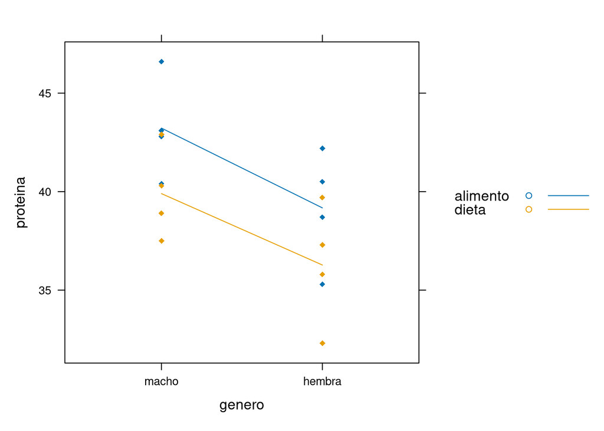

```r
library(lattice)
xyplot(proteina~genero,groups=cond,
pch=18,type=c("p","a"),auto.key=T)
```

Complementariamente, debe construirse un gráfico con los valores de **proteína** separados por **condición**.

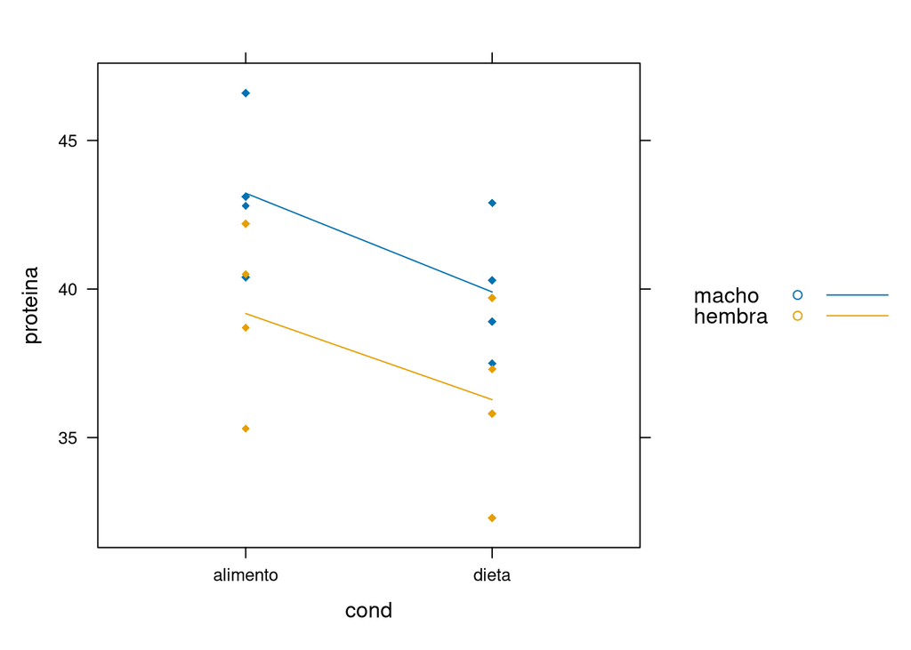

```r
xyplot(proteina~cond,groups=genero,
pch=18,type=c("p","a"),auto.key=T)
```

Obsérvese la distancia que hay entre cada par de medias para cada género, es decir, la media en alimento contra dieta para machos, y lo mismo para hembras. Esto puede realizárse con ambos gráficos para verificar que se obtiene la misma información, a pesar del hecho que seguramente alguno de ambos será de la predilección del investigador, pudiendo con ello optar por el uso de la sintaxis pertinente que más se adecúe a sus preferencias.

Finalmente, se observa que la distancia que hay entre la media de alimento respecto a la de dieta para los machos es muy similar a la distancia que hay para las hembras, así como también que en ambos casos (macho y hembra) la media de alimento es superior a la de dieta. Esto es una fuerte indicación de que no existe interacción entre condición y género o, dicho en otros términos, el nivel de proteína en sangre según el régimen alimenticio (dieta o alimentación libre) es independiente del sexo del animal.

## 4. Estimando las varianzas de los 4 tratamientos.

```r
v=tapply(proteina,list(cond,genero),var)
v
```

```
##             macho   hembra
## alimento 6.522500 8.715833
## dieta    5.306667 9.602500
```

Es recomendable verificar si se cumple el supuesto de homoscedasticidad. Para ello, puede utilizarse la prueba de Bartlet a través de la sintaxis `bartlett.test` indicando `Y~interaction(X1,X2)`.

```r
bartlett.test(proteina~interaction(cond,genero))
```

```
##
##  Bartlett test of homogeneity of variances
##
## data:  proteina by interaction(cond, genero)
## Bartlett's K-squared = 0.28408, df = 3, p-value = 0.963
```

Ante la hipótesis de homoscedasticidad se obtiene una probabilidad asociada de 0.96 al error tipo I ($\alpha=0.05$), por lo que se decide no rechazar esa hipótesis debido a que no se tiene evidencia de heteroscedasticidad. Así, se continúa suponiendo que los datos provienen de poblaciones cuyas variancias son iguales.

Tras la verificación de homogeneidad de varianza, obténgase una medida de la variabilidad del error asumiendo homoscedasticidad.

```r
v1=mean(v)
round(v1,2)
```

```
## [1] 7.54
```

## 5. Estimación de efectos simples e interacción

Para estimar los efectos simples y la interacción puede utilizarse la sintaxis `model.tables`. Debe escribirse primero el modelo con interacción entre **condición** y **especie** con la función `aov`. Además, recuérdese que la interacción se agrega a un modelo de cualquiera de las siguientes formas: `Y~X1+X2+X1:X2` o `Y~X1*X2`.

```r
mod1=aov(proteina~cond*genero)
model.tables(mod1)
```

```
## Tables of effects
##
##  cond
## cond
## alimento    dieta
##   1.5563  -1.5563
##
##  genero
## genero
##   macho  hembra
##  1.9187 -1.9187
##
##  cond:genero
##           genero
## cond       macho    hembra
##   alimento  0.10625 -0.10625
##   dieta    -0.10625  0.10625
```

Obtenidos los resultados anteriores, puede observarse que se obtienen los mismos efectos simples de la sección 3.

# 6. Configuración del Modelo Lineal

Puede construirse el modelo lineal mediante la sintaxis `lm` y almacenar el resultado en una estructura llamada `mod2`. Por defecto R usa el modelo de **tratamiento referencia**. Para cambiar al modelo de **suma nula**, que es el de interés en este tipo de investigaciones, debe escribirse `options(contrasts=c("contr.sum","contr.poly"))` antes de la línea de código de `mod2`.

```r
options(contrasts=c("contr.sum","contr.poly"))
mod2=lm(proteina~cond*genero)
```

Tras la estimación del modelo anterior, debe observarse la matriz de estructura usando `model.matrix(mod2)`. Verifíquese a qué corresponde cada columna poniendo atención a los códigos y relacionándolos con los niveles de cada factor.

```r
contrasts(cond)
```

```
##          [,1]
## alimento    1
## dieta      -1
```

```r
contrasts(genero)
```

```
##        [,1]
## macho     1
## hembra   -1
```

```r
model.matrix(mod2)
```

```
##    (Intercept) cond1 genero1 cond1:genero1
## 1            1     1       1             1
## 2            1     1       1             1
## 3            1     1       1             1
## 4            1     1       1             1
## 5            1    -1       1            -1
## 6            1    -1       1            -1
## 7            1    -1       1            -1
## 8            1    -1       1            -1
## 9            1     1      -1            -1
## 10           1     1      -1            -1
## 11           1     1      -1            -1
## 12           1     1      -1            -1
## 13           1    -1      -1             1
## 14           1    -1      -1             1
## 15           1    -1      -1             1
## 16           1    -1      -1             1
## attr(,"assign")
## [1] 0 1 2 3
## attr(,"contrasts")
## attr(,"contrasts")$cond
## [1] "contr.sum"
##
## attr(,"contrasts")$genero
## [1] "contr.sum"
```

Como puede observarse, la matriz de estructura tiene una columna para condición con códigos 1 y -1. Similarmente una columna para género con códigos 1 y -1; el -1 corresponde siempre al tratamiento que no aparece, que es dieta para hembras. La columna de interacción es el producto de las otras dos columnas.

En continuación de lo anterior, es recomendable extraer los coeficientes del modelo. Tras ello, el lector observará el efecto de la interacción entre factores. ¿Qué representa dicha cantidad?

```r
round(mod2$coef,2)
```

```
##   (Intercept)         cond1       genero1 cond1:genero1
##         39.64          1.56          1.92          0.11
```

Cuando dos factores interactúan, los efectos de un factor dependen del nivel en que se encuentre el otro factor. Cuando dos factores interactúan, el efecto de un factor va a depender del nivel en que se esté midiendo el otro factor, por lo que el efecto principal resulta difícil de interpretar. Los efectos de interacción son todos iguales en valor absoluto (0.11). Esto sucede por tratarse de un diseño dos a la dos. Esta cantidad representa cuánto se debe restar o sumar a la media observada en cada tratamiento para obtener promedios en condición de no interacción.

```r
anova(mod2)
```

```
## Analysis of Variance Table
##
## Response: proteina
##             Df Sum Sq Mean Sq F value  Pr(>F)
## cond         1 38.751  38.751  5.1415 0.04263 *
## genero       1 58.906  58.906  7.8157 0.01617 *
## cond:genero  1  0.181   0.181  0.0240 0.87955
## Residuals   12 90.443   7.537
## ---
## Signif. codes:  0 '***' 0.001 '**' 0.01 '*' 0.05 '.' 0.1 ' ' 1
```

La hipótesis nula que es de interés probar es si existe interacción entre condición y género. No interesa probar los efectos simples si no se ha eliminado la interacción. Formalmente:

$$H_o:(\alpha*\beta)_{ij}=0$$

En lenguaje natural, $H_o$ afirma que el efecto de la condición de alimento sobre la proteína promedio no depende del género, es decir, es el mismo en cualquiera de los dos géneros.

Para verificar la hipótesis nula anterior, es recomendable observar el Cuadrado Medio Residual (CMR) y compararlo con la estimación de la variancia del error obtenida más arriba. ¿Qué significa en este contexto el CMR?

```r
round(anova(mod2)[4,3],2)
```

```
## [1] 7.54
```

El valor obtenido coincide con la media de las varianzas obtenida anteriormente y es una medida de la variabilidad de la respuesta dentro de cada tratamiento.

Como complemento al CMR, se tiene el Cuadrado Medio de Interacción (CMI) es 0.18 y mide la magnitud general del efecto de interacción. Si esta magnitud tiende a ser pequeña, se tiene un caso con poca interacción, lo que sería una evidencia débil de interacción entre condición y especie. En caso contrario, si esta magnitud tiende a ser grande hay más evidencia de presencia de interacción.

Puede extraerse de la columna de cuadrados medios de tabla ANOVA, los cuadrados medios correspondientes a la interacción entre efectos y los cuadrados medios correspondientes a los residuos y dividirlos (siendo numerador y denominador, respectivamente) para obtener la proporción que la variabilidad de los efectos de interacción representan de la variabilidad residual.

```r
f=0.181/7.537
round(f,2)
```

```
## [1] 0.02
```

A la luz del resultado, la variabilidad de los efectos de interacción es sumamente baja con respecto a la variabilidad residual. Adicionalmente, se observó en la tabla ANOVA que la fiabilidad asociada a la probabilidad de cometer error tipo I (aquí $\alpha=0.05$) es de aproximadamente $p=0.88$, con lo cual se falla en rechazar la hipótesis de no-interacción. Se asume que el efecto de la condición de alimento es el mismo cuando se trata de machos que en el caso de las hembras, a la luz de las pruebas anteriores.